# ЛР3_R_Вар3_Галимова_МС3

Аделя Галимова

2024-12-13

# Лабораторная работа в среде R

## по 3 разделу “Дисперсионный анализ”

## Вариант 3

### Выполнила:

### Студентка БСТ233

### Галимова Аделя

# Раздел 3. Дисперсионный анализ (Anova)

## 3.1. Однофакторный дисперсионный анализ (One-Way ANOVA)

### 3.1.1. Основные понятия

Проведём дисперсионный анализ на примере данных из задачи $7.47$ из ДКР №3, где удельный объём выручки (тыс. руб./чел.) зависит от 2-ух факторов: численности населения места реализации продукции и соотношения заемных и собственных средств.

Загрузим *Excel*-таблицу с данными из задачи 7.47, а также установим библиотеку *`readxl`*:

```r
getwd()
```

```
## [1] "C:/Users/evere/Desktop/matstat"
```

```r
setwd('C:\\Users\\evere\\Desktop\\matstat')
library(readxl)
library('rio')
data = read_excel('var3.xlsx')
```

В данной таблице представлено $12$ наблюдений. Первая переменная: *ratio* - соотношение заемных и собственных средств, со значениями от $1$ до $3$, где $1$ - соотношение заемных и собственных средств от $0$ до $2$, где $2$ - соотношение заемных и собственных средств от $2$ до $6$ , где $3$ - соотношение заемных и собственных средств более $6$. Вторая переменная: *Population* - численность населения места реализации продукции, принимает 4 значения. Третья и последняя переменная: *Revenue* - информация об удельном объёме выручки. Откроем и выведем таблицу:

```r
data
```

```
## # A tibble: 12 × 3
##    ratio Population Revenue
##    <dbl> <chr>        <dbl>
##  1     1 0-10            26
##  2     2 0-10            30
##  3     3 0-10            28
##  4     1 10-50           29
##  5     2 10-50           28
##  6     3 10-50           33
##  7     1 50-100          33
##  8     2 50-100          31
##  9     3 50-100          29
## 10     1 более 100       34
## 11     2 более 100       35
## 12     3 более 100       36
```

Начнем с поиска **средних значений** по каждому показателю. Для этого используем функцию `tapply`, принимающую на вход $3$ аргумента: удельный объём выручки (для которого мы собираемся посчитать средние значения), численность населения (по которой мы группируем эти величины) и операция взятия среднего (то, что мы хотим получить). Таким образом мы получим значение *среднего размера выручки по численности населения места реализации продукции или по соотношению заемных и собственных средств*. Посмотрим, что получилось:

```r
meanPo = tapply(data$Revenue, data$Population, mean)
meanPo
```

```
##      0-10     10-50    50-100 более 100
##        28        30        31        35
```

Операция mean, то есть вычисление среднего арифметического, была применена к каждой группе. В результате мы получили 4 средних значения размера выручки.

Далее мы применим ту же операцию вычисления среднего, но теперь группировка будет идти по соотношению заёмных и собственных средств. Выполняем аналогичную операцию, и выводим соответствующие значения.

```r
meanRa = tapply(data$Revenue, data$ratio, mean)
meanRa
```

```
##    1    2    3
## 30.5 31.0 31.5
```

Мы видим, что в первом случае данные сгруппированны по $4$ группам, во втором - по $3$, а также вычисление среднего арифметического применено к каждой группе.

### 3.1.2. Графическое представление различий между средними изучаемых групп

Построим 2 графика, которые тоже сгруппируют значения удельной выручки по соответствующим уровням факторов, отдельно для соотношения средств и отдельно для численности населения. Сделаем 1-ую группировку по численности населения. Наша формула - это величины выручки в зависимости от численности населения места реализации, взятые из нашего набора данных. Посмотрим, что даст операция `stripchart()`:

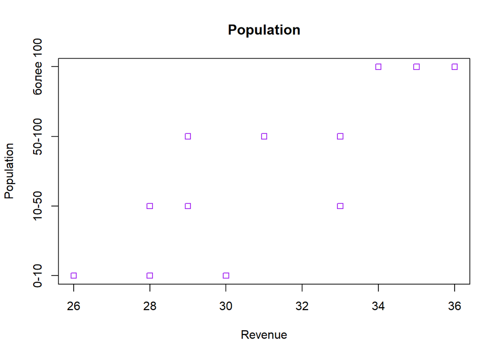

*Рис. 7. Точечный график зависимости величины удельной выручки от численности населения места реализации продукции (построен с помощью встроенной функции `stripchart`)*

```r
stripchart(Revenue ~ Population, data=data, col='purple',
           ylab='Population',
           xlab='Revenue', main='Population')
```

На графике (рис. $7$) по оси $X$ откладываются величины удельной выручки (тыс. руб./чел.), по оси $Y$ - категории фактора, т.е. удельную выручку для предприятий с местами реализации, где население от $0$ до $10$, от $10$ до $50$, от $50$ до $100$, более $100$ тысяч человек. Здесь можно заметить некоторую тенденцию, что в среднем значения удельной выручки предприятия с ростом населения места реализации прдукции увеличиваются. Тем не менее, визуально однозначного вывода сделать нельзя, нужно будет применить более строгие критерии. Аналогичный график мы построим для соотношения заёмных и собственных средств:

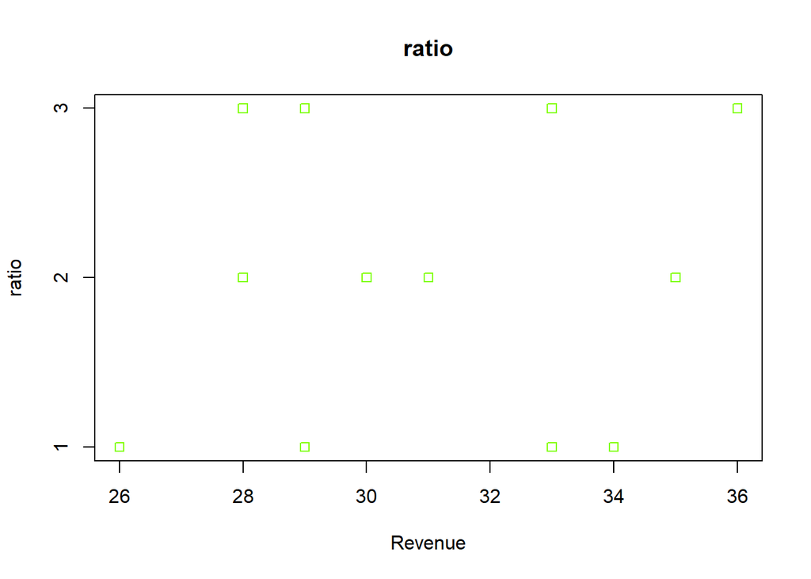

*Рис. 8. Точечный график зависимости величины удельной выручки от соотношения средств предприятия (построен с помощью встроенной функции `stripchart`)*

```r
stripchart(Revenue ~ ratio, data=data, col='chartreuse1',
           ylab='ratio',
           xlab='Revenue', main='ratio')
```

Кроме того, можно изобразить значения средних по численности населения места реализации продукции. В данном случае численность населения откладывается по оси $X$, а средние значения удельной выручки по оси $Y$. По этому графику мы также можем наблюдать тенденцию возрастания выручки по мере роста населения места реализации продукции:

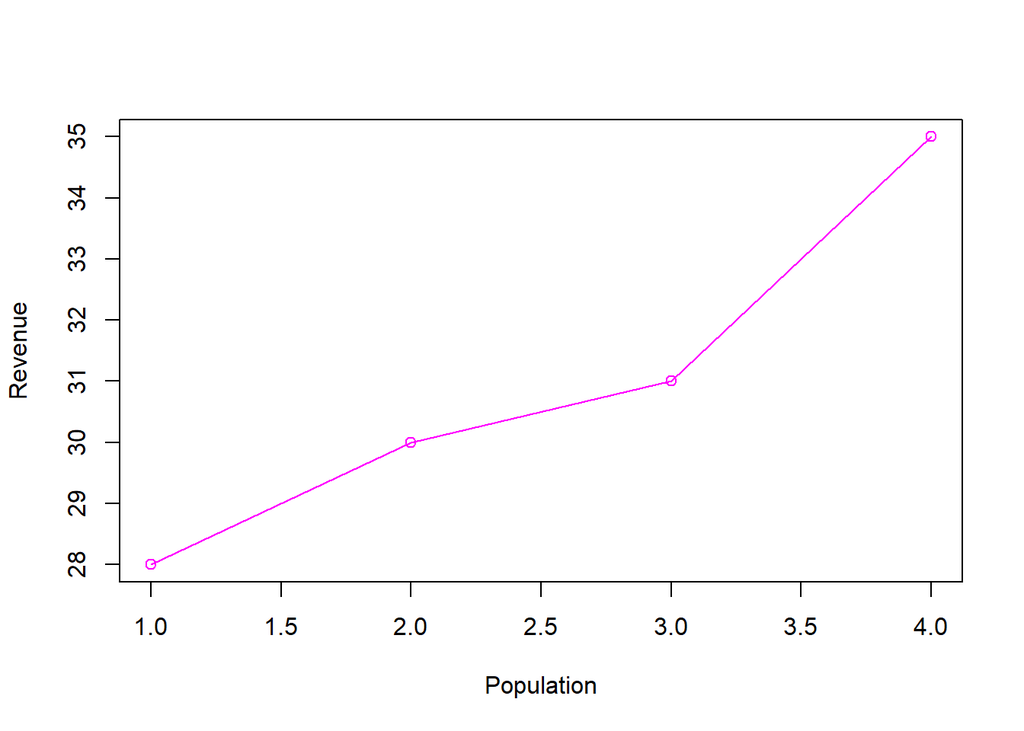

*Рис. 9. Точечный график зависимости средней величины удельной выручки от численности населения места реализации продукции (построен с помощью встроенной функции `plot`)*

```r
plot(meanPo, type='o', col='magenta',
     xlab='Population',
     ylab='Revenue')
```

Далее построим аналогичный график для соотношения заемных и собственных средств предприятия (рис.$10$):

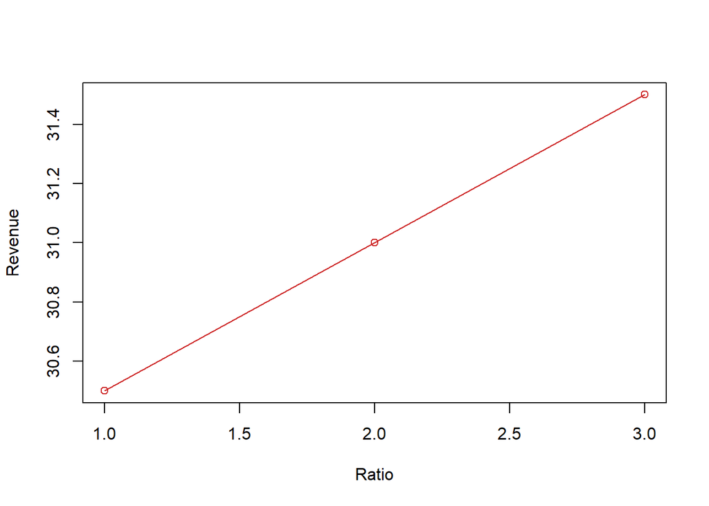

*Рис. 10. Точечный график зависимости средней величины удельной выручки от соотношения заемных и собственных средств предприятия (построен с помощью встроенной функции `plot`)*

```r
plot(meanRa, type='o', col='firebrick3',
     xlab='Ratio',
     ylab='Revenue')
```

Также на этапе предварительного анализа можно построить более информативные графики, например, `box plot`. Ящичковые диаграммы можно построить, сгруппировав наблюдения по численности населения или соотношению заемных и собственных средств предприятия.

Теперь построим график типа `box plot` для численности населения:

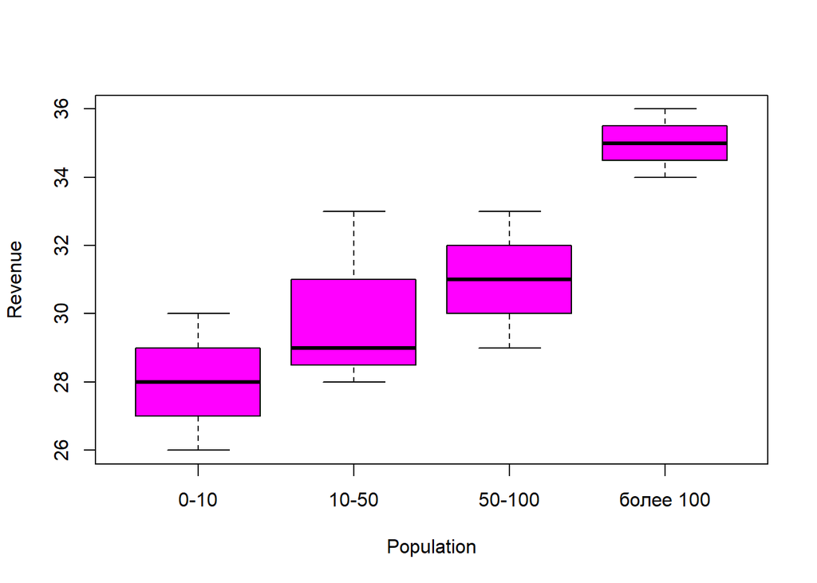

*Рис. 11. Ящичковая диаграмма (`box plot`) величины удельной выручки в зависимости от численности населения (построена с помощью встроенной функции `boxplot`)*

```r
boxplot(Revenue ~ Population, data=data, ylab='Revenue', col='magenta')
```

На рис. $11$ мы видим аналогичную с рис. $9$ ситуацию, то есть рост среднего значения удельной выручки для предприятий с большим по численности населения местом реализации продукции, т.е. среднее значение выручки для предприятий с местом реализации, где население более $100$ тыс. чел., значительно выше среднего значения для предприятий с местом реализации продукции, где численность населения от $50$ до $100$ тыс. чел. Благодаря подобным графикам мы уже можем видеть, что интерквартильные размахи групп незначительно пересекаются, а на уровне численности населения от $10$ до $50$ тыс. чел. величина удельной выручки наболее асимметричная, в то время как на уровне численности более $100$ тыс. чел. данные сгруппированы с наименьшей вариацией значений признака. Тем не менее вопрос «Являются ли эти различия статистически значимыми?» остается по-прежнему открытым.

Аналогичный график строим по категориям соотношения средств предприятия (рис. $12$):

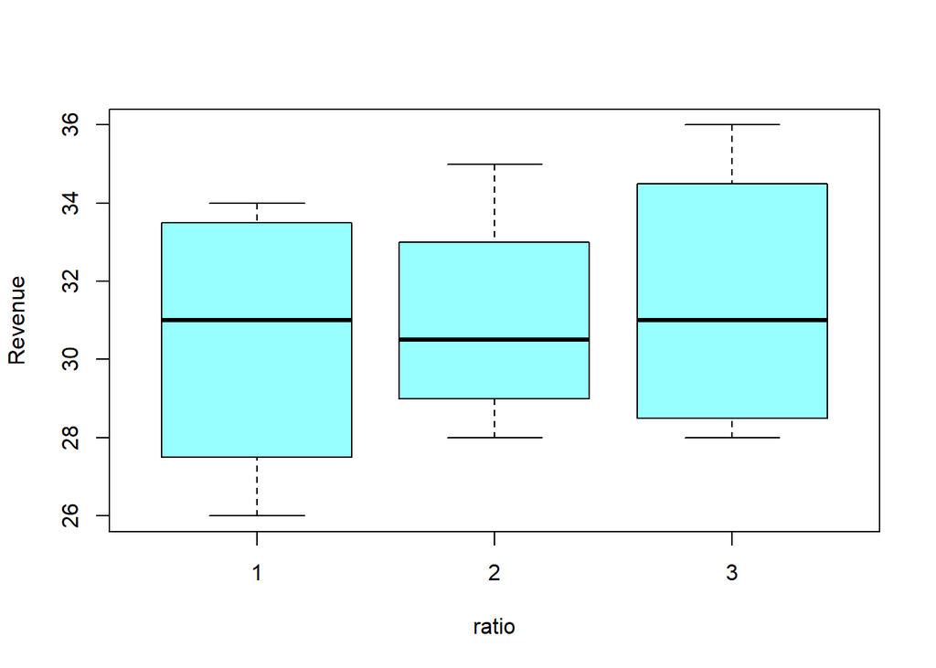

*Рис. 12. Ящичковая диаграмма (`box plot`) величины удельной выручки в зависимости от величины соотношения заемных и собственных средств предприятия (построена с помощью встроенной функции `boxplot`)*

```r
boxplot(Revenue ~ ratio, data=data, ylab='Revenue', col='darkslategray1')
```

На рис. $12$ та же тенденция, что и на графике средних (рис. $10$), то есть мы можем наблюдать рост удельной выручки в зависимости от типа соотношения средств предприятия, также при сравнении медиан в каждой группе соотношения средств тенденция роста неявна, но при этом интерквартильные размахи $3$-ёх групп значительно пересекаются. Тем не менее, мы все еще точно не можем утверждать, являются ли различия статистически значимыми.

Теперь построим скрипичную диаграмму для наших данных, но перед этим установим пакет *`ggplot2`*:

```r
library('ggplot2')
```

Установим категориальный (факторный) тип переменной *ratio*:

```r
data$ratio <- as.factor(data$ratio)
```

И зададим скрипичный график:

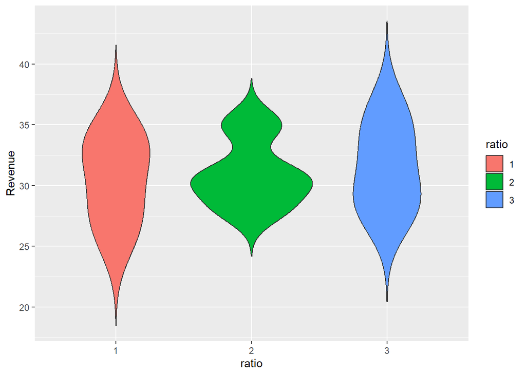

*Рис. 13.1. Скрипичная диаграмма (violin plot) величины удельной выручки предприятия в зависимости от типа соотношения заемных и собственных средств*

```r
p <- ggplot(data,
            aes(x=ratio, y=Revenue, fill= ratio)) + geom_violin(trim=FALSE)
p
```

Можно заметить, чтот параметр `trim` мы задали равным `FALSE`. Это для того чтобы на графике не были обрезаны хвосты распределений. Как можем наблюдать, рис. $13.1$ более информативен, чем рис. $12$ - мы имеем гораздо больше информации о распределении признака внутри каждой группы. Для удобства мы можем повернуть скрипичную диаграмму набок, то есть поменять оси местами (рис. $13.2$):

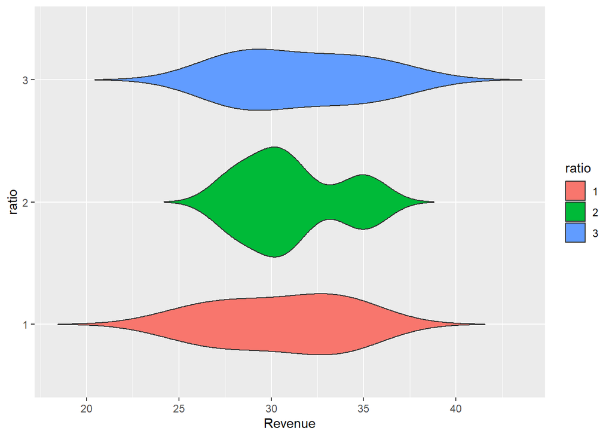

*Рис. 13.2. Перевернутая скрипичная диаграмма (violin plot) величины удельной выручки предприятия в зависимости от типа соотношения заемных и собственных средств*

```r
p + coord_flip()
```

Также в `среде R` есть возможность наложить на скрипичную диаграмму ящичковую (рис. $14.1$):

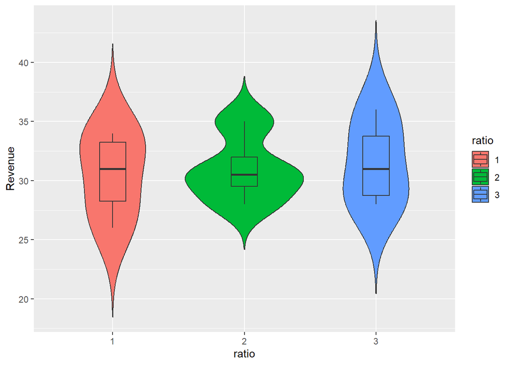

*Рис. 14.1. Скрипичная и ящичковая диаграммы величины удельной выручки предприятия в зависимости от типа соотношения заемных и собственных средств*

```r
p + geom_boxplot(width=0.2)
```

Функция наложения скрипичной диаграммы и диаграммы рассеяния также может оказаться удобной (рис. $14.2$):

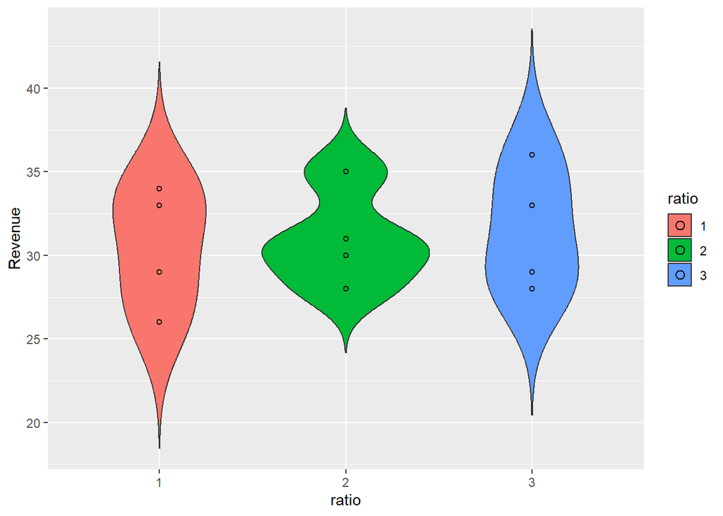

*Рис.14.2. Скрипичная диаграмма и диаграмма рассеяния величины удельного объёма выручки в зависимости от соотношения заемных и собственных средств*

```r
p + geom_dotplot(binaxis='y', stackdir='center', dotsize=1)
```

Установим категориальный (факторный) тип переменной $Population$:

```r
data$Population <- as.factor(data$Population)
```

И зададим скрипичный график:

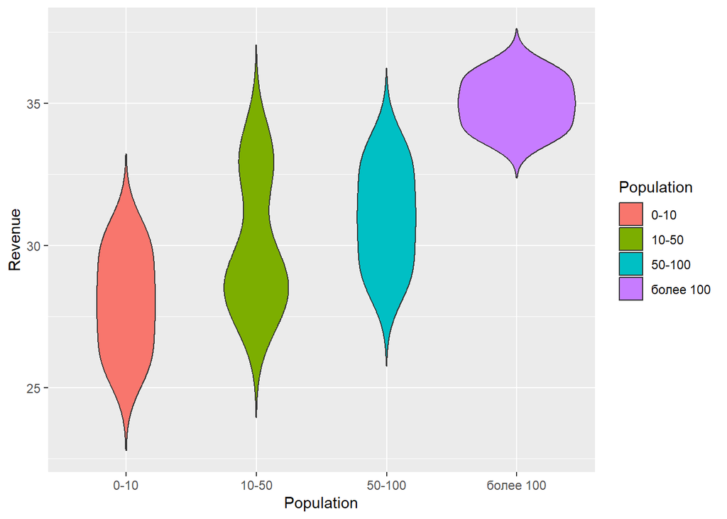

*Рис. 15.1. Скрипичная диаграмма (violin plot) величины удельного объёма выручки предприятия в зависимости от численности населения места реализации продукции*

```r
p1 <- ggplot(data,
            aes(x=Population, y=Revenue, fill= Population)) + geom_violin(trim=FALSE)
p1
```

Параметр `trim` мы задали равным `FALSE` для того, чтобы на графике не были обрезаны хвосты распределений. Как видим, диаграмма на рис. $15.1$ более информативна, чем на рис. $11$ - мы имеем гораздо больше информации о распределении признака внутри каждой группы. Для удобства мы можем повернуть скрипичную диаграмму набок - поменять оси местами (рис. $15.2$):

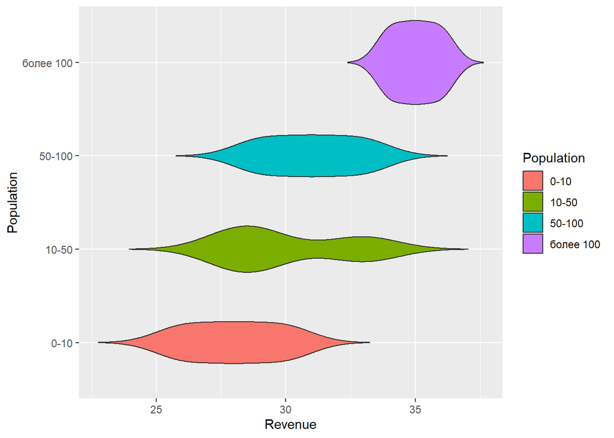

*Рис. 15.2. Перевернутая скрипичная диаграмма (violin plot) величины удельной выручки предприятия в зависимости от численности населения места реализации продукции*

```r
p1 + coord_flip()
```

Также в `среде R` есть возможность наложить на скрипичную диаграмму ящичковую (рис. $16.1$)

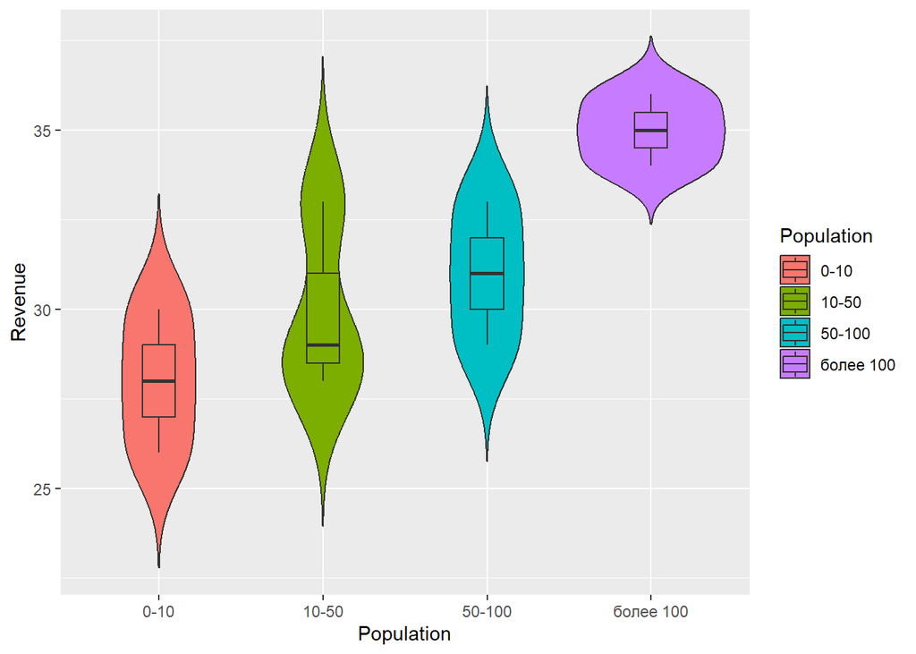

*Рис. 16.1. Скрипичная и ящичковая диаграммы величины удельного объёма выручки предприятия в зависимости от численности населения места реализации продукции*

```r
p1 + geom_boxplot(width=0.2)
```

Функция наложения скрипичной диаграммы и диаграммы рассеяния также может оказаться удобной (рис. $16.2$):

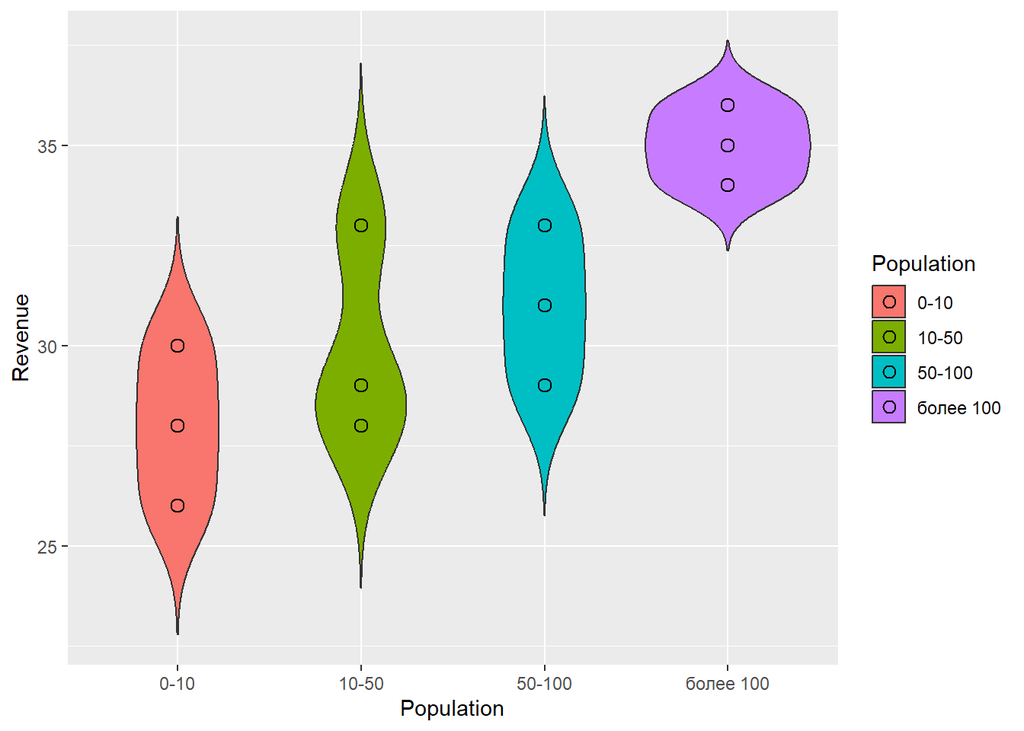

*Рис. 16.2. Скрипичная диаграмма и диаграмма рассеяния величины удельного объёма выручки предприятия в зависимости от численности населения места реализации продукции*

```r
p1 + geom_dotplot(binaxis='y', stackdir='center', dotsize=1)
```

### 3.1.3. Проведение однофакторного дисперсионного анализа в R

Перейдем непосредственно к дисперсионному анализу. Основными предпосылками к применению дисперсионного анализа являются требования, чтобы:

1. наблюдения подчинялись **нормальному закону**,
2. дисперсии в группах были примерно **равны**.

Перед применением статистических тестов визуально мы в том числе можем проверить, соответствует ли распределение удельной выручки предприятия нормальному, например, с помощью графика квантиль-квантиль (`quantile-quantile plot`). Построим такой график с помощью пакета *`car`* (рис. $17$).

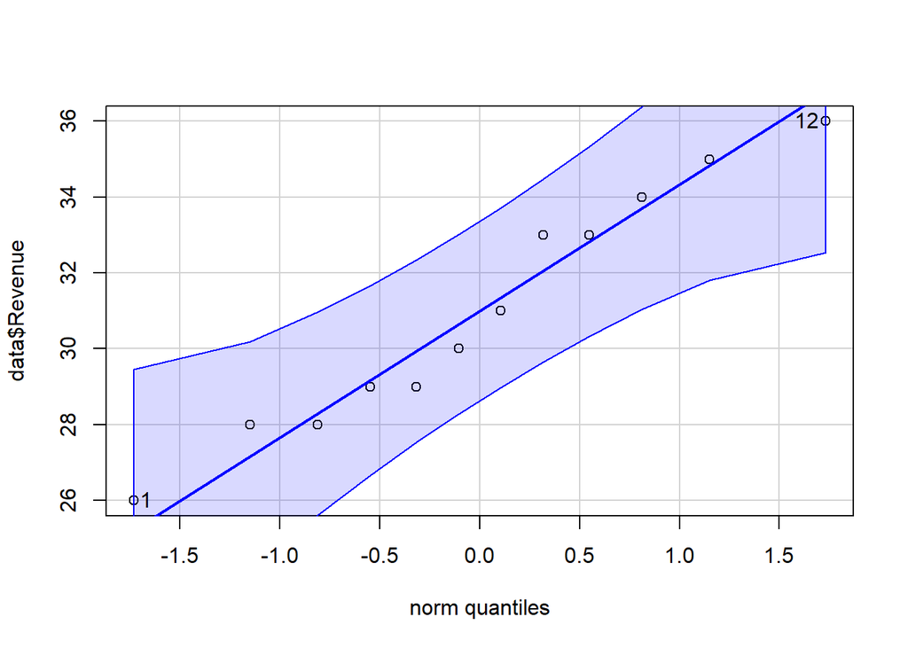

*Рис. 17. График квантиль-квантиль величины удельного объёма выручки и нормального распределения (построен с помощью функции `qqPlot` пакета* `car`*)*

```
## [1]  1 12
```

```r
library('car')
qqPlot(data$Revenue)
```

На графике (рис. $17$) можем визуально оценить подгонку теоретического распределения к наблюдаемым значениям. Мы можем наблюдать, что сопоставимость достаточно высока, точки наблюдаемых значений сосредоточены вдоль прямой равенства эмпирических и теоретических квантилей, поэтому можно предположить, что удельный объём выручки подчиняется **нормальному распределению**.

Теперь формально *проверим*, что наша выборка действительно *подчиняется нормальному распределению*. В данном случае переменной, используемой для проведения дисперсионного анализа, является удельный объём выручки. Именно для нее мы проверим гипотезу о нормальности. Для этого существует достаточно тестов, мы же применим *критерий Шапиро-Уилка*, наиболее подходящий для подобных малых выборок, как наша.

```r
shapiro.test(data$Revenue)
```

```
##
##  Shapiro-Wilk normality test
##
## data:  data$Revenue
## W = 0.9542, p-value = 0.6989
```

Как можем наблюдать, значение `p-value` = $0.6989$ больше заданного $5$% уровня значимости (да и любого разумного), значит, **нулевая гипотеза о соответствии зависимой переменной нормальному распределению в нашем случае не отвергается**, следовательно, мы можем применять дисперсионный анализ.

Теперь проверим 2-ую предпосылку применения дисперсионного анализа – однородность дисперсий между уровнями каждого фактора с помощью *теста Левене* – используем функцию `leveneTest` из пакета *`car`*.

Проверим тип наших переменных, поскольку `тест Левене` работает только с факторным типом данных:

```r
str(data$ratio)
```

```
##  Factor w/ 3 levels "1","2","3": 1 2 3 1 2 3 1 2 3 1 ...
```

```r
str(data$Population)
```

```
##  Factor w/ 4 levels "0-10","10-50",..: 1 1 1 2 2 2 3 3 3 4 ...
```

Получили, что обе переменные - **факторные**, что необходимо для корректного проведения дисперсионного анализа.

Теперь можно провести *тест Левене* с медианами по умолчанию и средними дополнительно:

```r
leveneTest(data$Revenue, data$ratio)
```

```
## Levene's Test for Homogeneity of Variance (center = median)
##       Df F value Pr(>F)
## group  2  0.5217 0.6104
##        9
```

```r
leveneTest(data$Revenue, data$ratio, center=mean)
```

```
## Levene's Test for Homogeneity of Variance (center = mean)
##       Df F value Pr(>F)
## group  2     0.6 0.5694
##        9
```

В обоих случаях `p-value` ($0.6104$ и $0.5694$) больше любого разумного уровня значимости, поэтому **нулевая гипотеза об однородности дисперсий между группами фактора соотношения заемных и собственных средств не отвергается**.

То же самое проводим с фактором численности населения места реализации:

```r
leveneTest(data$Revenue, data$Population)
```

```
## Levene's Test for Homogeneity of Variance (center = median)
##       Df F value Pr(>F)
## group  3  0.2879  0.833
##        8
```

```r
leveneTest(data$Revenue, data$Population, center=mean)
```

```
## Levene's Test for Homogeneity of Variance (center = mean)
##       Df F value Pr(>F)
## group  3  0.8889 0.4872
##        8
```

В обоих случаях `p-value` ($0.833$ и $0.4872$) больше любого разумного уровня значимости, поэтому **нулевая гипотеза об однородности дисперсий между группами фактора численности населения тоже не отвергается**.

Итак, все предпосылки применения дисперсионного анализа проверены, в таком случае можем приступать к самому анализу.

Дисперсионный анализ в пакете R реализуем функцией `aov()` — *analysis of variance*, анализ дисперсии. Но несмотря на свое название, дисперсионный анализ проверяет гипотезу о равенстве средних, а не дисперсий. То есть анализируются дисперсии, но вывод получается о том, равны ли средние при разных уровнях фактора или нет.

Для начала мы проверим гипотезу о том, что значения удельного объёма выручки равны в среднем по всем видам численности населения места реализации продукции. Для этого выполним дисперсионный анализ и сразу выведем результаты. То есть мы в операцию `summary()` подставляем операцию *analysis of variance* – используем вложенную функцию. В данном случае эта команда выполнит нам однофакторный дисперсионный анализ для фактора “численность населения”. То есть на **2-ой фактор** в данном случае мы не обращаем внимания, как будто его нет. Перед нами появляется таблица с основными результатами.

Нулевая гипотеза, проверяемая в дисперсионном анализе - что средние всех уровней фактора численности населения места реализации продукции равны (фактор не влияет на зависимую переменную $Y$):

```r
summary(aov(data$Revenue ~ data$Population))
```

```
##                 Df Sum Sq Mean Sq F value Pr(>F)
## data$Population  3     78      26     6.5 0.0154 *
## Residuals        8     32       4
## ---
## Signif. codes:  0 '***' 0.001 '**' 0.01 '*' 0.05 '.' 0.1 ' ' 1
```

В данном случае мы должны посмотреть на значение `p-value` = $0.0154$, и оно меньше, чем $0.05$ - заданный уровень значимости. Соответственно: **гипотеза о равенстве средних по уровням данного фактора отвергается на уровне значимости $\alpha = 0.05$**. Следовательно, можно сделать вывод о том, что *численность населения места реализации продукции предприятия влияет на удельный объём его выручки*.

Проведём аналогичный анализ для 2-ой переменной - **типа соотношения заёмных и собственных средств предприятия**. Это будет тоже однофакторный дисперсионный анализ без рассмотрения другого фактора.

```r
summary(aov(data$Revenue ~ data$ratio))
```

```
##             Df Sum Sq Mean Sq F value Pr(>F)
## data$ratio   2      2       1   0.083  0.921
## Residuals    9    108      12
```

## 3.2. Двухфакторный дисперсионный анализ (Two-Way ANOVA)

Проведём двухфакторный дисперсионный анализ, когда в рассмотрение будут включены оба фактора.

### 3.2.1. Без учета взаимодействия факторов ($n=1$)

Поскольку в исходной таблице было по одному наблюдению в каждой ячейке, мы не можем рассматривать эффект взаимодействия факторов. То есть просто добавляем теперь влияние 2-ух факторов в нашу модель:

```r
summary(aov(data$Revenue ~ data$ratio + data$Population))
```

```
##                 Df Sum Sq Mean Sq F value Pr(>F)
## data$ratio       2      2       1     0.2 0.8240
## data$Population  3     78      26     5.2 0.0417 *
## Residuals        6     30       5
## ---
## Signif. codes:  0 '***' 0.001 '**' 0.01 '*' 0.05 '.' 0.1 ' ' 1
```

В данном случае дисперсии немного перераспределились, как раз по 2-ум предположительно влияющим факторам. У нас часть дисперсии объясняется фактором численности населения места реализации продукции, часть дисперсии объясняется влиянием типа соотношения средств предприятия, и также, естественно, присутствует остаточная дисперсия. Сами эти значения (суммы квадратов) указаны во 2-ом столбце.

### 3.2.2. Проверка равенства средних выбранных уровней (*post hoc tests*) – *тест Тьюки*

Тесты на проверку равенства средних конкретных уровней изучаемого фактора – так называемые *рost hoc тесты* являются важным и ценным инструментом в дисперсионном анализе. Они позволяют сравнить средние 2-ух интересующих нас выбранных уровней и ответить на важный для исследователя вопрос (на который не отвечает проведение дисперсионного анализа в рассмотренном выше виде – там мы отвечаем только на вопрос “есть ли между хотя бы какими-либо уровнями различия, или их нет”) – “между какими уровнями фактора различия существенны, а между какими не являются статистически значимыми”.

Тест Тьюки - это наиболее распространенный и рекомендуемый тест, один из тех тестов, которые позволяют учитывать поправку на множественную проверку гипотез, при этом не являясь слишком консервативными и не теряя в статистической значимости результатов. Размеры наших выборок одинаковы, поэтому будем использовать именно его.

Проведем тест Тьюки `TukeyHSD` для сравнения среднего удельного объёма выручки предприятия между численностью населения места реализации его продукции:

```r
anova_data <- aov(data$Revenue ~ data$Population)
summary(anova_data)
```

```
##                 Df Sum Sq Mean Sq F value Pr(>F)
## data$Population  3     78      26     6.5 0.0154 *
## Residuals        8     32       4
## ---
## Signif. codes:  0 '***' 0.001 '**' 0.01 '*' 0.05 '.' 0.1 ' ' 1
```

```r
TukeyHSD(anova_data)
```

```
##   Tukey multiple comparisons of means
##     95% family-wise confidence level
##
## Fit: aov(formula = data$Revenue ~ data$Population)
##
## $`data$Population`
##                  diff        lwr       upr     p adj
## 10-50-0-10          2 -3.2294189  7.229419 0.6297636
## 50-100-0-10         3 -2.2294189  8.229419 0.3245304
## более 100-0-10      7  1.7705811 12.229419 0.0113928
## 50-100-10-50        1 -4.2294189  6.229419 0.9252929
## более 100-10-50     5 -0.2294189 10.229419 0.0609499
## более 100-50-100    4 -1.2294189  9.229419 0.1441838
```

Результат проведения теста Тьюки приведён в нижней части кода: в первом столбце содержатся номера сравниваемых групп, во втором - оценка разницы в уровнях, в третьем и четвёртом - нижняя и верхняя границы $95$%-го доверительного интервала, а последний столбец содержит в себе `p-value`.

Как можно видеть, почти для всех групп доверительный интервал содержит $0$, а `p-value` превышают значение $0.05$, вследствие чего **нулевая гипотеза о равенстве средних не отвергается на заданном уровне значимости**. Однако для одной группы (`более 100` и `0 - 10`, строка 3) **нулевая гипотеза отвергается с вероятностью ошибки $0.05$**, поскольку `p-value`=$0.0114$ < $\alpha = 0.05$, а соответствующий доверительный интервал не включает в себя $0$.

Сейчас покажем наглядно полученные результаты теста, построив $95$-процентные доверительные интервалы для всех категорий численности населения места реализации продукции (рис. $18$):

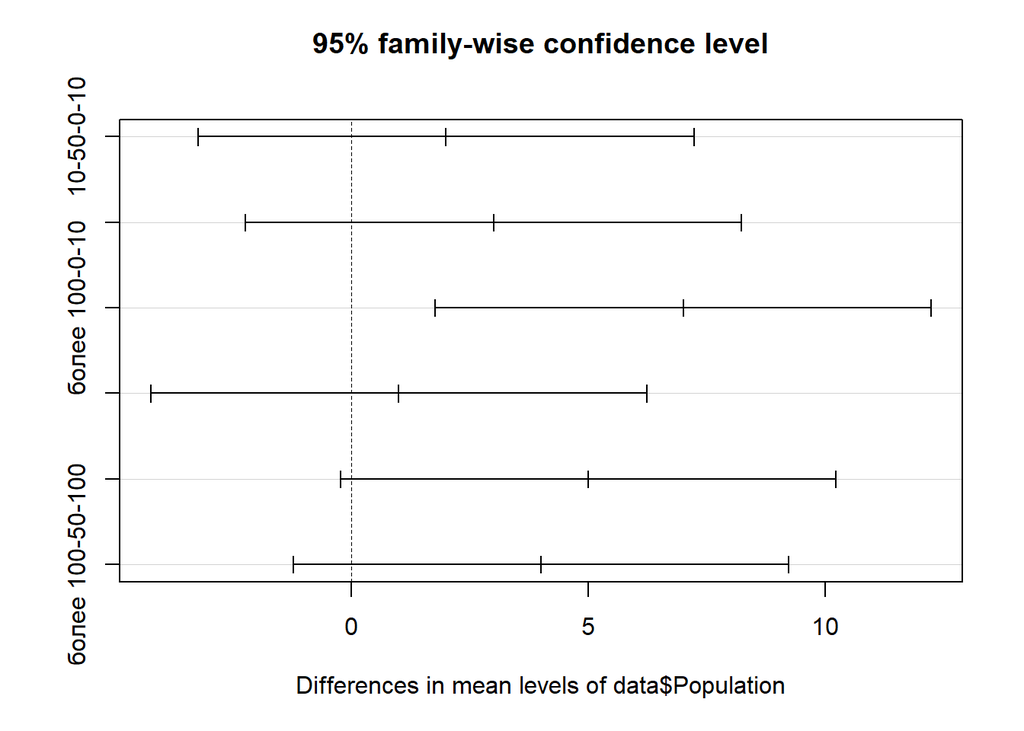

*Рис. 18. Доверительные интервалы с надежностью 0,95 для разницы средних выборных категорий численности населения места реализации продукции*

```r
tukey <- TukeyHSD(anova_data)
plot(tukey, col='gray0')
```

Эта визуализация подтверждает полученные выше результаты - как можно видеть, почти для всех групп доверительный интервал содержит $0$, вследствие чего **нулевая гипотеза о равенстве средних не отвергается на заданном уровне значимости** (левая граница доверительного интервала - отрицательна, правая положительна - т.е. не можем сказать, у какого из уровней фактора больше, а у какого меньше средний удельный объём выручки согласно доверительному интервалу).

Однако для группы (более $100$ и $0 - 10$, сверху $3$-й график) доверительный интервал не включает в себя $0$ - поэтому **нулевая гипотеза для этой пары средних отвергается с вероятностью ошибки $\alpha = 0.05$**, и различия между этими уровнями фактора численности населения статистически значимы. Иначе говоря, удельный объём выручки существенно различается лишь у предприятий с местом реализации, где численность населения *более 100 тыс. чел.* и также где численность *менее 10 тыс. чел.*

Теперь проведем тест Тьюки `TukeyHSD` для сравнения среднего удельного объёма выручки от типа соотношения заемных и собственных средств предприятия:

```r
anova_data1 <- aov(data$Revenue ~ data$ratio)
summary(anova_data1)
```

```
##             Df Sum Sq Mean Sq F value Pr(>F)
## data$ratio   2      2       1   0.083  0.921
## Residuals    9    108      12
```

```r
TukeyHSD(anova_data1)
```

```
##   Tukey multiple comparisons of means
##     95% family-wise confidence level
##
## Fit: aov(formula = data$Revenue ~ data$ratio)
##
## $`data$ratio`
##     diff       lwr      upr     p adj
## 2-1  0.5 -6.338989 7.338989 0.9773493
## 3-1  1.0 -5.838989 7.838989 0.9130865
## 3-2  0.5 -6.338989 7.338989 0.9773493
```

Результат проведения теста Тьюки приведён в нижней части кода. Как можем наблюдать, доверительный интервал для всех групп содержит $0$, а `p-value` превышают $0.05$, вследствие чего **нулевая гипотеза о равенстве средних не отвергается на заданном уровне значимости**.

Этот вывод подтверждается результатами проверки основной гипотезы дисперсионного анализа, представленными в верхней части кода: `p-value` ($𝐹_{набл.}$) = $0.921 > \alpha = 0.05$, вследствие чего **нулевая гипотеза о равенстве средних выбранных уровней не отвергается на уровне значимости** $\alpha = 0.05$, то есть соотношение заемных и собственных средств предприятия не влияет на удельный объём его выручки или по данной выборке влияние фактора не доказано.

Теперь можем визуализировать полученные результаты теста, построив $95%$-ные доверительные интервалы для всех типов соотношения средств (рис. $19$):

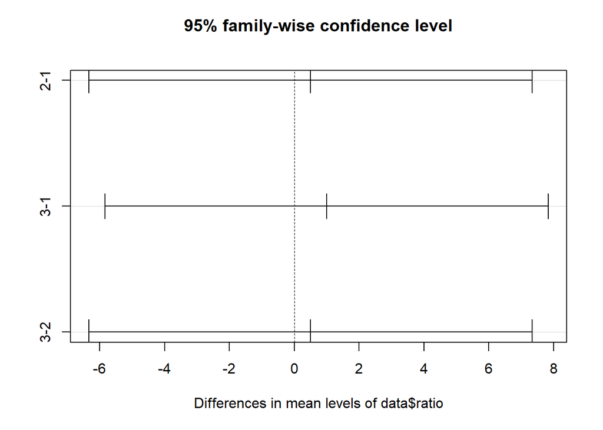

*Рис. 19. Доверительные интервалы с надежностью 0,95 для разницы средних выборных в зависимости от соотношения заемных и собственных средств предприятия*

```r
tukey <- TukeyHSD(anova_data1)
plot(tukey)
```

Эта визуализация подтверждает полученные выше результаты - как можно видеть, для всех групп доверительный интервал содержит $0$, вследствие чего **нулевая гипотеза о равенстве средних не отвергается на заданном уровне значимости** (левая граница доверительного интервала отрицательна, правая положительна - т.е. непонятно, у какого из уровней фактора больше, а у какого меньше средний удельный объём выручки согласно доверительному интервалу).